# CFE Tree Cover Study

Bradley Saul

2019-06-17

# Study Design

The design was based on the random point sampling described in Kaspar et al. (2017). 2500 points each were selected in the rural buffer and county owned lands, plus 1500 points in the county outside the buffer and county lands. Using a [custom web application](https://github.com/bsaul/ocForestCover), users labeled each point as TREE, NOT TREE, or UNSURE based on NC Onemap [orthoimagery from 2008 and 2017](http://data.nconemap.gov/geoportal/catalog/raster/download.page). For power calculations, we assumed the study areas had 65% tree cover in 2008. Based on a type 1 error rate of 0.05, the study was designed to have 80% statistical power to detect a change in tree cover of ~3% within both the rural buffer and county lands.

The figure below shows all the points selected in the study. The purple points are the rural buffer; the red are county-owned lands; and the green are points in the county excluding the rural buffer or county-owned lands.

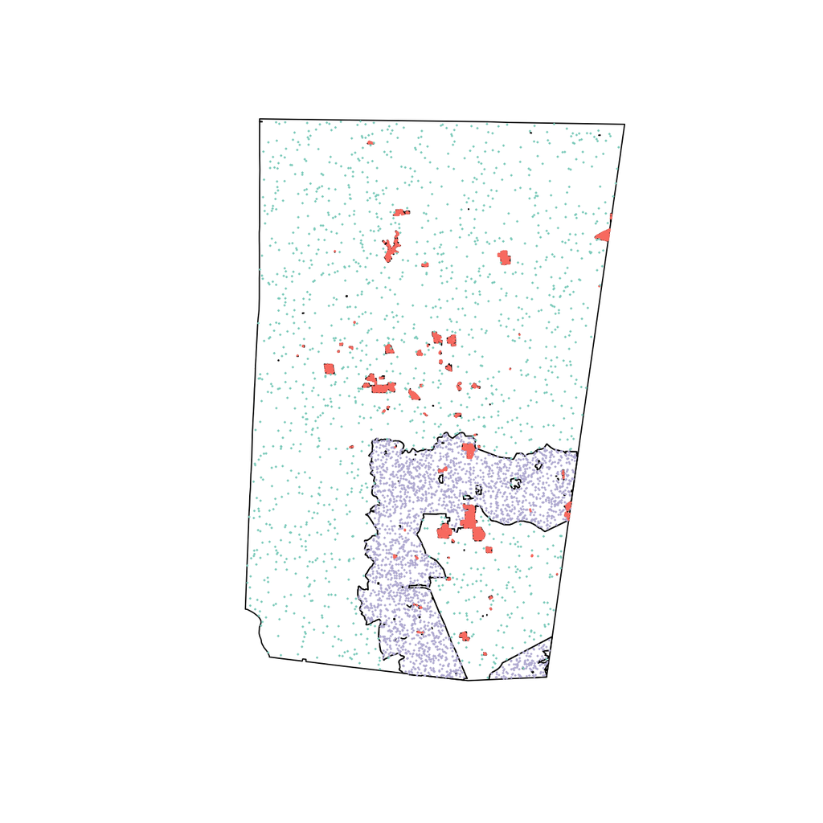

The application measured intra- and interrater reliability by displaying points that had previously been identified by the same user or another user with a probablity of 0.15.

# Study Results

7 people participated in the identification of points. In total, 16294 identifications were made, and 6312 points had at least one identification for both years (97% of the available points).

| Area | 2008 | 2017 | Both years | Proportion of available points |
| --- | --- | --- | --- | --- |
| Orange County owned property | 2470 | 2458 | 2429 | 0.97 |
| County excluding rural buffer and OC property | 1483 | 1481 | 1464 | 0.98 |
| Rural buffer | 2466 | 2452 | 2419 | 0.97 |
| Overall | 6419 | 6391 | 6312 | 0.97 |

## Rater Reliability

### Intrarater

Number of times the same user identified the same point/year

| # of times | # of point/years |
| --- | --- |
| 1 | 14491 |
| 2 | 835 |
| 3 | 43 |
| 4 | 1 |

In the 879 point/years where a given user identified the same point/year more than once, the following table shows the number of point/years and the proportion of those point/years were each user agreed on all their identifications of that point/year.

Agreement per user

| User | Number of point/years | Proportion of Agreement |
| --- | --- | --- |
| A | 47 | 0.87 |
| C | 326 | 0.95 |
| E | 38 | 0.95 |
| G | 393 | 0.94 |
| H | 75 | 0.97 |

Patterns of Intrarater disagreement

| Pattern | n |
| --- | --- |
| NNT | 1 |
| NNU | 2 |
| NT | 32 |
| NTT | 1 |
| NU | 4 |
| TTU | 2 |
| TU | 6 |

### Interrater

Number of users who identified a point/year

| # of different users | # of point/years |
| --- | --- |
| 1 | 10463 |
| 2 | 2144 |
| 3 | 194 |
| 4 | 8 |
| 5 | 1 |

Excluding the point/years considered for intrarater reliablity, the proportion of point/years where there was complete interrater reliability was 0.9.

Patterns of Interrater Disagreement

| Patterns | n |
| --- | --- |
| NNNNT | 1 |
| NNT | 5 |
| NNTT | 1 |
| NNU | 5 |
| NT | 95 |
| NTT | 11 |
| NU | 33 |
| TTU | 3 |
| TU | 56 |
| TUU | 3 |
| TUUU | 1 |

## Paired Analysis

### Handling Disagreements

Based on the intra- and interrater reliablity assessments, which generally showed good agreement, the following algorithm was chosen for point/years with disagreement:

- the majority rules in cases where more than half of the identifications (by any user and/or multiple by the same user) were a particular value; e.g., “NNT” $\mapsto$ “N”; “TTU” $\mapsto$ “T”; “TUU” $\mapsto$ “U”; etc.
- all others are set to “U”

### Results

The following table shows the observed pattern in `2008 -> 2017` tree cover in each of the three areas in our study after applying the voting algorithm described above.

Observed proportions of patterns of change in tree cover

| Pattern | OC property | County Excluding RB and OC prop | Rural Buffer |
| --- | --- | --- | --- |
| N -> N | 0.346 | 0.301 | 0.175 |
| N -> T | 0.046 | 0.077 | 0.072 |
| N -> U | 0.016 | 0.018 | 0.019 |
| T -> N | 0.019 | 0.047 | 0.036 |
| T -> T | 0.516 | 0.495 | 0.633 |
| T -> U | 0.041 | 0.036 | 0.046 |
| U -> N | 0.004 | 0.008 | 0.005 |
| U -> T | 0.009 | 0.017 | 0.012 |
| U -> U | 0.002 | 0.001 | 0.001 |

Most often a “U” indicates that the user was unable to make an identification because an image failed to load rather than being uncertain about an identification. That is, a “U” identification is unlikely to depend on the actual state of a point or the user. Hence, we assume the “U” identifications are [missing completely at random](https://en.wikipedia.org/wiki/Missing_data#Missing_completely_at_random), and exclude all points with a “U” in either year is excluded from our primary analysis.

The following table shows tree cover patterns after excluding these points.

Observed Proportions of Patterns of change in tree cover

| Pattern | OC property | County Excluding RB and OC prop | Rural Buffer |
| --- | --- | --- | --- |
| N -> N | 0.373 | 0.327 | 0.191 |
| N -> T | 0.050 | 0.083 | 0.079 |
| T -> N | 0.020 | 0.051 | 0.039 |
| T -> T | 0.557 | 0.538 | 0.691 |

The following table shows the estimated change in tree cover for each study area with an adjusted Wald 95% confidence interval for matched pairs (Agresti and Min 2005; Scherer 2018).

Estimated change in tree cover 2008-2017

| Area | Estimate (95% CI) |
| --- | --- |
| Orange County owned property | 0.030 (0.0294, 0.0301) |
| County excluding rural buffer and OC property | 0.032 (0.0313, 0.0325) |
| Rural buffer | 0.040 (0.0397, 0.0406) |

# Comparison to other studies

Giorgino et al. (2018) Table 2 and 3 showed loss of forest land type in 3 OC watersheds from 1991-2011 by roughly 5-7%. The figure below presents data from their study.

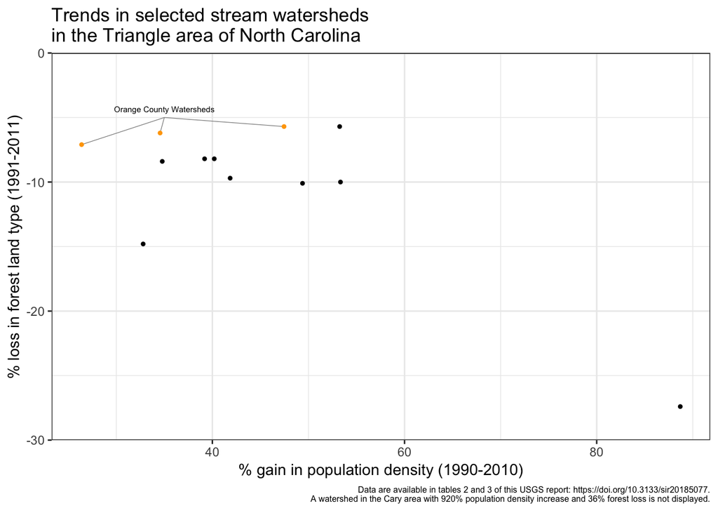

# Validation

The following table shows the validation pattern (rows) vs the observed pattern (column):

```
##       o
## v      N->N N->T T->N T->T
##   N->N   77    3    1    1
##   N->T    3   10    0    2
##   T->N    0    0    5    2
##   T->T    4    8    3  171
```

Futher analyses could use (e.g.) Hidden Markov Models to try to account for measurement error treating the underlying state of a point as a latent state or an approach such as Magder and Hughes (1997) could be considered. This is beyond the scope of this analysis.

# Summary

Our study suggests tree cover appears stable and may have increased from 2008 to 2017 on Orange County owned property, the rural buffer surrounding Chapel Hill and Carrboro, and the rest of the county excluding the first two areas.

# Lessons Learned

- overlap probability unnecessarily high
- exclude Lake Orange from county-owned property?
- send out regular updates on the status of the identifications
- app needs work to speed up image loading times

# References

Agresti, Alan, and Yongyi Min. 2005. “Simple Improved Confidence Intervals for Comparing Matched Proportions.” *Statistics in Medicine* 24 (5). Wiley Online Library: 729–40.

Giorgino, Mary J, Thomas F Cuffney, Stephen L Harden, and Toby D. Feaster. 2018. “Trends in Water Quality of Selected Streams and Reservoirs Used for Water Supply in the Triangle Area of North Carolina, 1989–2013.” 2018-5077. USGS. https://doi.org/10.3133/sir20185077.

Kaspar, J., D. Kendal, R. Sore, and S.J. Livesley. 2017. “Random Point Sampling to Detect Gain and Loss in Tree Canopy Cover in Response to Urban Densification.” *Urban Forestry & Urban Greening*.

Magder, Laurence S, and James P Hughes. 1997. “Logistic Regression When the Outcome Is Measured with Uncertainty.” *American Journal of Epidemiology* 146 (2). Oxford University Press: 195–203.

Scherer, Ralph. 2018. *PropCIs: Various Confidence Interval Methods for Proportions*. https://CRAN.R-project.org/package=PropCIs.